# test01 copy

## Performance Analysis

This report helps you better understand the risks within your portfolios held at AFE-N2N and at other financial institutions which you may have shared with us. This report presents portfolio characteristics, as well as estimates of portfolio volatility and stress test results. The report estimates volatility by analyzing the positions in your portfolio. Commonly, the higher the volatility, the riskier is the security or portfolio. Stress testing is available to illustrate how your portfolio might react under a certain market scenario or set of events.

The purpose of the Suitability Benchmark is to assist you in understanding the risk in your portfolio referenced in this report against your stated risk profile. The Suitability Benchmark may be different than the one used to compare your portfolio performance. The Report allows you to review and compare the results of the Risk Analysis of your Current Portfolio against a Suitability Benchmark, and hypothetical Alternate Portfolio, if depicted, of positions that you may or may not own, or may not own in the same quantities. The Alternate Portfolio, if depicted in this report, including the asset allocation and particular securities in the Alternate Portfolio, are hypothetical illustrations only.

AFE-N2N is not recommending that you adopt the hypothetical Alternate Portfolio shown in this Report or any of its components. Rather, we are presenting it so that you have a basis for comparison when you consider the risk characteristics of your current holdings. After discussing with you the analyses in this Report, and your ability and willingness to take risk, your Financial Advisor can work with you to construct a portfolio that meets your needs.

The Hypothetical Results Illustrated in this Report for Your Current Portfolio and/or Alternate Portfolio are not and should NOT be construed as a guarantee of future performance. The factor models used to generate these results may contain errors or faulty assumptions.

Please refer to the Important Disclosures and Glossary at the end of this Report for additional information, including a description of the assumptions and methodologies used throughout and definitions of key terminology.

### Asset Allocation

|  | categories | last month | current | difference |
| --- | --- | --- | --- | --- |
| 0 | EQUITIES | 0.231499 | 0.703946 | 0.472447 |
| 1 | FIXED INCOME & PREFERREDS | 0.000000 | 0.000000 | 0.000000 |
| 2 | ALTERNATIVES | 0.003882 | 0.000000 | -0.003882 |
| 3 | CASH | 0.764619 | 0.000000 | -0.764619 |

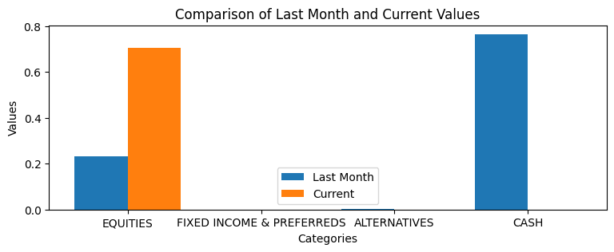

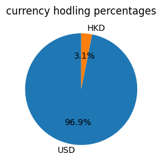

### Holding

Current portfolio backtesting in last 2 years performance and each component cumulative return plot as below:

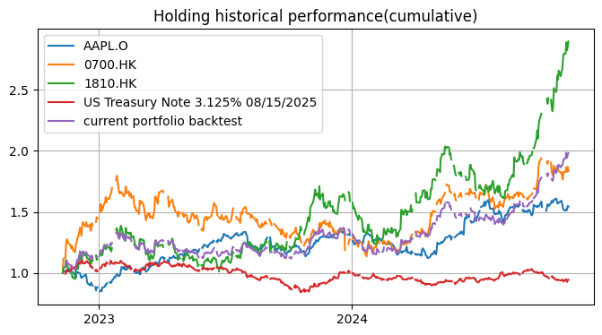

Portfolio components in last 1, 3 and 6 month performance.

| instrument | percentage | gross_return(1m) | max drawdown(1m) | volatility(1m) | gross_return(3m) | max drawdown(3m) | volatility(3m) | gross_return(6m) | max drawdown(6m) | volatility(6m) |
| --- | --- | --- | --- | --- | --- | --- | --- | --- | --- | --- |
| AAPL.O | 0.085663 | -0.002593 | 0.061189 | 0.010998 | 0.025715 | 0.061189 | 0.012216 | 0.218381 | 0.117494 | 0.014646 |
| 0700.HK | 0.207647 | -0.041021 | 0.077940 | 0.019926 | 0.111463 | 0.089969 | 0.016441 | 0.112639 | 0.115365 | 0.015941 |
| 1810.HK | 0.410635 | 0.191579 | 0.044211 | 0.022177 | 0.674556 | 0.049231 | 0.021742 | 0.461777 | 0.208208 | 0.021801 |
| US Treasury Note 3.125% 08/15/2025 | 0.296054 | -0.013941 | 0.047765 | 0.010291 | -0.046706 | 0.102264 | 0.007870 | 0.021581 | 0.102264 | 0.008404 |

## Market Risk

Portfolio components in last 1, 3 and 6 month risk metrics.

| instrument | percentage | VaR | CVaR | risk_contribution |
| --- | --- | --- | --- | --- |
| AAPL.O | 0.085663 | 0.021623 | 0.030285 | 0.016483 |
| 0700.HK | 0.207647 | 0.027510 | 0.038596 | 0.244160 |
| 1810.HK | 0.410635 | 0.035294 | 0.045083 | 0.699012 |
| US Treasury Note 3.125% 08/15/2025 | 0.296054 | 0.016104 | 0.019843 | 0.040345 |

### Portfolio in last 2 years' hypothetical performance of each quater

Each quater the portfolio's simulated gross return and drawdown

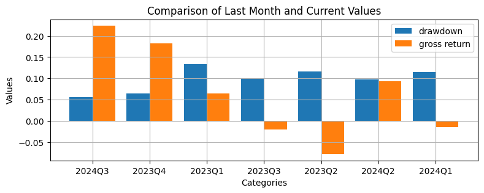

## Liquity Risk

Your holding quality and daily traded volume of last 30 days. If Holding/ADTV is large, you should pay more attention to liquity risk.

|  | ADTV | Holding | Holding/ADTV |
| --- | --- | --- | --- |
| AAPL.O | 42767395.0 | 100.0 | 0.000002 |
| 0700.HK | 24893448.0 | 1000.0 | 0.000040 |
| 1810.HK | 188096910.0 | 30000.0 | 0.000159 |
| US Treasury Note 3.125% 08/15/2025 | 263.0 | 1000.0 | 3.802281 |

## Concentration Risk

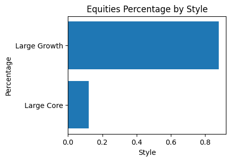

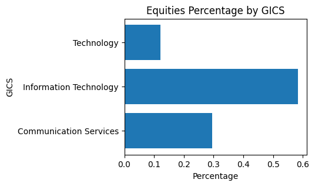

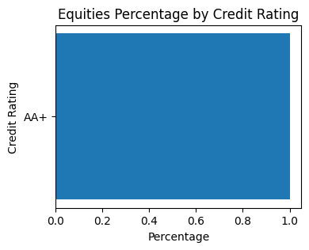

Your stock positions are largely concentrated in large growth or information technology categories, and your bond holdings are mostly rated AA+.

## Correlation and tail risk

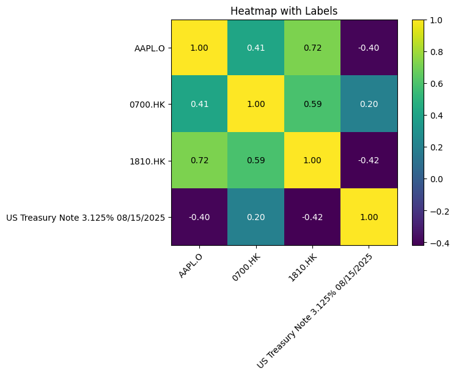

Correlation Risk:

High correlations (such as the 0.72 between AAPL.O and 1810.HK) suggest that these assets tend to move in the same direction, which can increase the overall risk of the portfolio during market downturns. Low or negative correlations (such as the -0.40 between the US Treasury Note and AAPL.O) can provide benefits of diversification, as these assets tend to move in opposite directions.